# FUNDAMENTOS ESTADISTICA R

EJERCICIO

2021

## 1 Introduction

This is a short lab on Statistical Inference with R.  
Through the lab you will practice R Base comands for:

- Sampling from a (population) dataset: random amd stratified sampling
- Frequencies: absolute and relative
- Descriptive statistics:
  - Measures of Center: mean, median, mode
  - Order Satistics and Quantiles: quantiles and quartiles
  - Measures of Spread: Variance, Standard Deviation, Interquartile Range, Median Absolute Deviation
  - Measures of Shape: Skewness, Kurtosis
- Common Distributions
  - Bernoulli
  - Binomial
  - Poisson
  - Normal
- Parameter Estimation
  - Point estimation
  - Interval estimation
- Hipothesis Testing
  - 1-way test
  - 2-way test

## 2 Preparing the Data

We are going to work with the classical wine quality datasets https://archive.ics.uci.edu/ml/datasets/Wine+Quality.  
Load both datasets (red and white wine), join them and see the variables inside:

```r
redwine = read.table(file="winequality-red.csv", na.strings=c("", "NA"), sep=";", header = TRUE)
redwine$color = "red"
whitewine = read.table(file="winequality-white.csv", na.strings=c("", "NA"), sep=";", header = TRUE)
whitewine$color = "white"
wine = rbind(redwine, whitewine)
str(wine)
```

```
## 'data.frame':    6497 obs. of  13 variables:
##  $ fixed.acidity       : num  7.4 7.8 7.8 11.2 7.4 7.4 7.9 7.3 7.8 7.5 ...
##  $ volatile.acidity    : num  0.7 0.88 0.76 0.28 0.7 0.66 0.6 0.65 0.58 0.5 ...
##  $ citric.acid         : num  0 0 0.04 0.56 0 0 0.06 0 0.02 0.36 ...
##  $ residual.sugar      : num  1.9 2.6 2.3 1.9 1.9 1.8 1.6 1.2 2 6.1 ...
##  $ chlorides           : num  0.076 0.098 0.092 0.075 0.076 0.075 0.069 0.065 0.073 0.071 ...
##  $ free.sulfur.dioxide : num  11 25 15 17 11 13 15 15 9 17 ...
##  $ total.sulfur.dioxide: num  34 67 54 60 34 40 59 21 18 102 ...
##  $ density             : num  0.998 0.997 0.997 0.998 0.998 ...
##  $ pH                  : num  3.51 3.2 3.26 3.16 3.51 3.51 3.3 3.39 3.36 3.35 ...
##  $ sulphates           : num  0.56 0.68 0.65 0.58 0.56 0.56 0.46 0.47 0.57 0.8 ...
##  $ alcohol             : num  9.4 9.8 9.8 9.8 9.4 9.4 9.4 10 9.5 10.5 ...
##  $ quality             : int  5 5 5 6 5 5 5 7 7 5 ...
##  $ color               : chr  "red" "red" "red" "red" ...
```

```r
wine$alcohol = as.numeric(wine$alcohol)
typeof(wine$alcohol)
```

```
## [1] "double"
```

Also, we need to create a new variable “class” acording to the wine quality:

- class = “excellent”, if quality > 7
- class = “good”, if quality in == 7
- class = “regular”, if quality in [5, 6]
- class = “poor”, if quality < 5

```r
wine$class = "nothing yet"
wine$class[ wine$quality %in% c(8,9) ] = "1 Excellent"
wine$class[ wine$quality == 7 ] = "2 Good"
wine$class[ wine$quality %in% c(5,6) ] = "3 Regular"
wine$class[ wine$quality <= 4 ] = "4 Poor"
str(wine)
```

```
## 'data.frame':    6497 obs. of  14 variables:
##  $ fixed.acidity       : num  7.4 7.8 7.8 11.2 7.4 7.4 7.9 7.3 7.8 7.5 ...
##  $ volatile.acidity    : num  0.7 0.88 0.76 0.28 0.7 0.66 0.6 0.65 0.58 0.5 ...
##  $ citric.acid         : num  0 0 0.04 0.56 0 0 0.06 0 0.02 0.36 ...
##  $ residual.sugar      : num  1.9 2.6 2.3 1.9 1.9 1.8 1.6 1.2 2 6.1 ...
##  $ chlorides           : num  0.076 0.098 0.092 0.075 0.076 0.075 0.069 0.065 0.073 0.071 ...
##  $ free.sulfur.dioxide : num  11 25 15 17 11 13 15 15 9 17 ...
##  $ total.sulfur.dioxide: num  34 67 54 60 34 40 59 21 18 102 ...
##  $ density             : num  0.998 0.997 0.997 0.998 0.998 ...
##  $ pH                  : num  3.51 3.2 3.26 3.16 3.51 3.51 3.3 3.39 3.36 3.35 ...
##  $ sulphates           : num  0.56 0.68 0.65 0.58 0.56 0.56 0.46 0.47 0.57 0.8 ...
##  $ alcohol             : num  9.4 9.8 9.8 9.8 9.4 9.4 9.4 10 9.5 10.5 ...
##  $ quality             : int  5 5 5 6 5 5 5 7 7 5 ...
##  $ color               : chr  "red" "red" "red" "red" ...
##  $ class               : chr  "3 Regular" "3 Regular" "3 Regular" "3 Regular" ...
```

```r
summary(wine)
```

```
##  fixed.acidity    volatile.acidity  citric.acid     residual.sugar
##  Min.   : 3.800   Min.   :0.0800   Min.   :0.0000   Min.   : 0.600
##  1st Qu.: 6.400   1st Qu.:0.2300   1st Qu.:0.2500   1st Qu.: 1.800
##  Median : 7.000   Median :0.2900   Median :0.3100   Median : 3.000
##  Mean   : 7.215   Mean   :0.3397   Mean   :0.3186   Mean   : 5.443
##  3rd Qu.: 7.700   3rd Qu.:0.4000   3rd Qu.:0.3900   3rd Qu.: 8.100
##  Max.   :15.900   Max.   :1.5800   Max.   :1.6600   Max.   :65.800
##    chlorides       free.sulfur.dioxide total.sulfur.dioxide
##  Min.   :0.00900   Min.   :  1.00      Min.   :  6.0
##  1st Qu.:0.03800   1st Qu.: 17.00      1st Qu.: 77.0
##  Median :0.04700   Median : 29.00      Median :118.0
##  Mean   :0.05603   Mean   : 30.53      Mean   :115.7
##  3rd Qu.:0.06500   3rd Qu.: 41.00      3rd Qu.:156.0
##  Max.   :0.61100   Max.   :289.00      Max.   :440.0
##     density             pH          sulphates         alcohol
##  Min.   :0.9871   Min.   :2.720   Min.   :0.2200   Min.   : 8.00
##  1st Qu.:0.9923   1st Qu.:3.110   1st Qu.:0.4300   1st Qu.: 9.50
##  Median :0.9949   Median :3.210   Median :0.5100   Median :10.30
##  Mean   :0.9947   Mean   :3.219   Mean   :0.5313   Mean   :10.49
##  3rd Qu.:0.9970   3rd Qu.:3.320   3rd Qu.:0.6000   3rd Qu.:11.30
##  Max.   :1.0390   Max.   :4.010   Max.   :2.0000   Max.   :14.90
##     quality         color              class
##  Min.   :3.000   Length:6497        Length:6497
##  1st Qu.:5.000   Class :character   Class :character
##  Median :6.000   Mode  :character   Mode  :character
##  Mean   :5.818
##  3rd Qu.:6.000
##  Max.   :9.000
```

Let’s see some frequency tables to understand the data

```r
table(wine$quality)
```

```
##
##    3    4    5    6    7    8    9
##   30  216 2138 2836 1079  193    5
```

```r
table(wine$class)
```

```
##
## 1 Excellent      2 Good   3 Regular      4 Poor
##         198        1079        4974         246
```

```r
table(wine$color)
```

```
##
##   red white
##  1599  4898
```

```r
table(wine$color, wine$class)
```

```
##
##         1 Excellent 2 Good 3 Regular 4 Poor
##   red            18    199      1319     63
##   white         180    880      3655    183
```

Now we are ready to play!

## 3 Sampling

### 3.1. Random Sampling

A random sample means that each element/row of the original dataset, has the same probability of being sampled/extracted.

In order to extract a random sample from a dataset, we need to sample the row indexes of the dataset. An then extract that sampled rows.

Here we extract a random sample of size=6

```r
set.seed(1) # use a seed to extrat the same random sample each time you run this code
index_sample = sample(x = 1:nrow(wine), size = 6)
wine_sample_rnd = wine[index_sample, ]
wine_sample_rnd
```

```
##      fixed.acidity volatile.acidity citric.acid residual.sugar chlorides
## 1017           8.9             0.38        0.40           2.20     0.068
## 4775           7.8             0.21        0.34          11.90     0.039
## 2177           7.1             0.22        0.33           2.80     0.033
## 5026           7.1             0.17        0.40          14.55     0.047
## 1533           7.2             0.53        0.13           2.00     0.058
## 4567           6.6             0.23        0.30          14.90     0.051
##      free.sulfur.dioxide total.sulfur.dioxide density   pH sulphates
## 1017                  12                   28 0.99486 3.27      0.75
## 4775                  55                  140 0.99590 3.02      0.31
## 2177                  48                  153 0.98990 3.15      0.38
## 5026                  47                  156 0.99945 3.34      0.78
## 1533                  18                   22 0.99573 3.21      0.68
## 4567                  33                  118 0.99835 3.04      0.54
##      alcohol quality color     class
## 1017    12.6       7   red    2 Good
## 4775    10.3       6 white 3 Regular
## 2177    12.7       7 white    2 Good
## 5026     9.1       6 white 3 Regular
## 1533     9.9       6   red 3 Regular
## 4567     9.0       6 white 3 Regular
```

### 3.2. Stratified Sampling

A stratified sample is always defined for a categorical variable (or set of categorical variables), commonly named as strata. Then, for the data inside each possible category a random sample is extracted.

In order to extract a stratified sample from a dataset, we need to:  
0. Load the “sampling” library 1. Define the strata variables 2. Sort the dataset according to the strata variables (this is important to later define the sample sizes) 3. See the cross-categories for the strata variables (after sorting) 4. Define the sample size for each category 5. Run the stratified sampling

let’s do a simple example using the variable “color” as strata

```r
# 0. Load the "sampling" library
library(sampling)
# 1. Define the strata variables
strata_vars = c("color")
# 2. Sort the dataset according to the strata variables
wine = wine[ order(wine[ ,strata_vars]), ]
# 3. See the cross-categories for the strata variables
table(wine[strata_vars])
```

```
##
##   red white
##  1599  4898
```

```r
# 4. Define the sample size for each category (2 reds and 5 wines)
stratum_size = c(2, 5)
# 5. Run the stratified sampling
st = strata(data = wine, stratanames = strata_vars, size = stratum_size, method="srswor")
wine_sample_str = getdata(wine, st)
wine_sample_str
```

```
##      fixed.acidity volatile.acidity citric.acid residual.sugar chlorides
## 270           11.5            0.180        0.51            4.0     0.104
## 299            7.2            0.650        0.02            2.3     0.094
## 2196           6.9            0.410        0.33           10.1     0.043
## 2900           9.0            0.245        0.38            5.9     0.045
## 4978           6.1            0.280        0.27            4.7     0.030
## 5649           6.8            0.160        0.36            1.3     0.034
## 5664           5.5            0.280        0.21            1.6     0.032
##      free.sulfur.dioxide total.sulfur.dioxide density   pH sulphates
## 270                    4                   23 0.99960 3.28      0.97
## 299                    5                   31 0.99930 3.67      0.80
## 2196                  28                  152 0.99680 3.20      0.52
## 2900                  52                  159 0.99500 2.93      0.35
## 4978                  56                  140 0.99042 3.16      0.42
## 5649                  32                   98 0.99058 3.02      0.58
## 5664                  23                   85 0.99027 3.42      0.42
##      alcohol quality       class color ID_unit        Prob Stratum
## 270     10.1       6   3 Regular   red     270 0.001250782       1
## 299      9.7       5   3 Regular   red     299 0.001250782       1
## 2196     9.4       5   3 Regular white    2196 0.001020825       2
## 2900    10.2       6   3 Regular white    2900 0.001020825       2
## 4978    12.5       8 1 Excellent white    4978 0.001020825       2
## 5649    11.3       6   3 Regular white    5649 0.001020825       2
## 5664    12.5       5   3 Regular white    5664 0.001020825       2
```

```r
table(wine_sample_str[strata_vars])
```

```
##
##   red white
##     2     5
```

Now let’s do something more complex: using the strata variables “color” and “class” make a stratified sample of size:

- red-excellent = 1,
- red-good = 2,
- red-regular = 3,
- red-poor = 4,
- white-excellent = 5,
- white-good = 6,
- white-regular = 7, and finally
- white-poor = 8

```r
# 0. Load the "sampling" library
library(sampling)
# 1. Define the strata variables
strata_vars = c("color", "class")
# 2. Sort the dataset according to the strata variables
wine = wine[  order(wine[ ,strata_vars[1]], wine[ ,strata_vars[2]]), ]
# 3. See the cross-categories for the strata variables
table(wine[strata_vars])
```

```
##        class
## color   1 Excellent 2 Good 3 Regular 4 Poor
##   red            18    199      1319     63
##   white         180    880      3655    183
```

```r
# 4. Define the sample size for each category
stratum_size = c(1, 2, 3, 4, 5, 6, 7, 8)
# 5. Run the stratified sampling
st = strata(data = wine, stratanames = strata_vars, size = stratum_size, method="srswor")
wine_sample_str2 = getdata(wine, st)
table(wine_sample_str2[strata_vars])
```

```
##        class
## color   1 Excellent 2 Good 3 Regular 4 Poor
##   red             1      2         3      4
##   white           5      6         7      8
```

NOTE that you need to sort the data according to the strata variables and then define the sample size for each stratum using that order

## 4 Frequencies for categorical variables

### 4.1. Absolute frequencies

Frequency table for the categorical variable “color”

```r
table(wine$color)
```

```
##
##   red white
##  1599  4898
```

Frequency table for the categorical variable “color” X “class”

```r
table(wine$color, wine$class)
```

```
##
##         1 Excellent 2 Good 3 Regular 4 Poor
##   red            18    199      1319     63
##   white         180    880      3655    183
```

### 4.2. Relative frequencies

Relative frequency table for the categorical variable “color”

```r
prop.table(table(wine$color))
```

```
##
##       red     white
## 0.2461136 0.7538864
```

Relative frequency table for the categorical variable “color” X “class”

```r
prop.table(table(wine$color, wine$class))
```

```
##
##         1 Excellent      2 Good   3 Regular      4 Poor
##   red   0.002770509 0.030629521 0.203016777 0.009696783
##   white 0.027705095 0.135447129 0.562567339 0.028166846
```

## 5. Descriptive Statistics

The summary() function in R gives some descriptive statistics for each variable in a dataset

```r
summary(wine, na.rm = T)
```

```
##  fixed.acidity    volatile.acidity  citric.acid     residual.sugar
##  Min.   : 3.800   Min.   :0.0800   Min.   :0.0000   Min.   : 0.600
##  1st Qu.: 6.400   1st Qu.:0.2300   1st Qu.:0.2500   1st Qu.: 1.800
##  Median : 7.000   Median :0.2900   Median :0.3100   Median : 3.000
##  Mean   : 7.215   Mean   :0.3397   Mean   :0.3186   Mean   : 5.443
##  3rd Qu.: 7.700   3rd Qu.:0.4000   3rd Qu.:0.3900   3rd Qu.: 8.100
##  Max.   :15.900   Max.   :1.5800   Max.   :1.6600   Max.   :65.800
##    chlorides       free.sulfur.dioxide total.sulfur.dioxide
##  Min.   :0.00900   Min.   :  1.00      Min.   :  6.0
##  1st Qu.:0.03800   1st Qu.: 17.00      1st Qu.: 77.0
##  Median :0.04700   Median : 29.00      Median :118.0
##  Mean   :0.05603   Mean   : 30.53      Mean   :115.7
##  3rd Qu.:0.06500   3rd Qu.: 41.00      3rd Qu.:156.0
##  Max.   :0.61100   Max.   :289.00      Max.   :440.0
##     density             pH          sulphates         alcohol
##  Min.   :0.9871   Min.   :2.720   Min.   :0.2200   Min.   : 8.00
##  1st Qu.:0.9923   1st Qu.:3.110   1st Qu.:0.4300   1st Qu.: 9.50
##  Median :0.9949   Median :3.210   Median :0.5100   Median :10.30
##  Mean   :0.9947   Mean   :3.219   Mean   :0.5313   Mean   :10.49
##  3rd Qu.:0.9970   3rd Qu.:3.320   3rd Qu.:0.6000   3rd Qu.:11.30
##  Max.   :1.0390   Max.   :4.010   Max.   :2.0000   Max.   :14.90
##     quality         color              class
##  Min.   :3.000   Length:6497        Length:6497
##  1st Qu.:5.000   Class :character   Class :character
##  Median :6.000   Mode  :character   Mode  :character
##  Mean   :5.818
##  3rd Qu.:6.000
##  Max.   :9.000
```

### 5.1. Measures of Center

#### Mean

Let’s calculate the mean quality

```r
mean(wine$quality, na.rm = T)
```

```
## [1] 5.818378
```

Now let’s calculate the mean for all numerical variables

```r
numeric_cols = sapply(wine, is.numeric)
apply(X = wine[, numeric_cols], MARGIN = 2, FUN = mean, na.rm = T)
```

```
##        fixed.acidity     volatile.acidity          citric.acid
##           7.21530706           0.33966600           0.31863322
##       residual.sugar            chlorides  free.sulfur.dioxide
##           5.44323534           0.05603386          30.52531938
## total.sulfur.dioxide              density                   pH
##         115.74457442           0.99469663           3.21850085
##            sulphates              alcohol              quality
##           0.53126828          10.49180083           5.81837771
```

What is the quality mean by color?

```r
aggregate(wine[, c("quality")], list(wine$color), mean, na.rm=T)
```

```
##   Group.1        x
## 1     red 5.636023
## 2   white 5.877909
```

What is the quality mean by color and class?

```r
aggregate(x = wine$quality, list( wine$class, wine$color), mean, na.rm=T)
```

```
##       Group.1 Group.2        x
## 1 1 Excellent     red 8.000000
## 2      2 Good     red 7.000000
## 3   3 Regular     red 5.483700
## 4      4 Poor     red 3.841270
## 5 1 Excellent   white 8.027778
## 6      2 Good   white 7.000000
## 7   3 Regular   white 5.601368
## 8      4 Poor   white 3.890710
```

#### Weighted Arithmetic Mean

```r
salary = c(20, 25, 27, 30, 19, 29, 33)
n = c(1500, 400, 380, 333, 5050, 1350, 300)
weighted.mean(x = salary, w = n)
```

```
## [1] 22.03909
```

#### Median

Let’s calculate the median quality

```r
median(wine$quality, na.rm = T)
```

```
## [1] 6
```

Now let’s calculate the median for all numerical variables

```r
numeric_cols = sapply(wine, is.numeric)
apply(X = wine[, numeric_cols], MARGIN = 2, FUN = median, na.rm = T)
```

```
##        fixed.acidity     volatile.acidity          citric.acid
##              7.00000              0.29000              0.31000
##       residual.sugar            chlorides  free.sulfur.dioxide
##              3.00000              0.04700             29.00000
## total.sulfur.dioxide              density                   pH
##            118.00000              0.99489              3.21000
##            sulphates              alcohol              quality
##              0.51000             10.30000              6.00000
```

What is the quality median by color?

```r
aggregate(wine[, c("quality")], list(wine$color), median, na.rm=T)
```

```
##   Group.1 x
## 1     red 6
## 2   white 6
```

What is the quality median by color and class?

```r
aggregate(x = wine$quality, list( wine$class, wine$color), median, na.rm=T)
```

```
##       Group.1 Group.2 x
## 1 1 Excellent     red 8
## 2      2 Good     red 7
## 3   3 Regular     red 5
## 4      4 Poor     red 4
## 5 1 Excellent   white 8
## 6      2 Good   white 7
## 7   3 Regular   white 6
## 8      4 Poor   white 4
```

#### Mode

Let’s calculate the mode for quality

```r
w = table(wine$quality)
w[max(w)==w]
```

```
##    6
## 2836
```

Let’s calculate the mode for alcohol

```r
w = table(wine$alcohol)
w[max(w)==w]
```

```
## 9.5
## 367
```

### 5.2. Order Satistics and Quantiles

The P-order statistics for a variable (with 0 < p < 1) is the variable value that has a p-% of observations smaller than itself.

The most important order statistics are:

- 1st Quartile, p=0.25
- 2nd Quartile, p=0.50
- 3th Quartile, p=0.75

Let’s calculate the order statistics with p = (0,01, 0.25, 0.50, 0.75, 0.99) for the variable “residual.sugar”

```r
quantile(wine$residual.sugar, probs = c(0.01, 0.25, 0.50, 0.75, 0.99))
```

```
##   1%  25%  50%  75%  99%
##  0.9  1.8  3.0  8.1 18.2
```

The median is the 50% quantile

```r
median(wine$residual.sugar, na.rm = T)
```

```
## [1] 3
```

What is the residual.sugar 25%-quantile by color?

```r
aggregate(x = wine$residual.sugar, list(wine$color), function(x) {quantile(x, probs = 0.25)})
```

```
##   Group.1   x
## 1     red 1.9
## 2   white 1.7
```

### 5.3. Measures of Spread

#### Standard Deviation (Sample Variance)

The variance measures the mean squared distance from each observation to the sample mean.

Let’s calculate the standard deviation of quality

```r
sd(wine$quality, na.rm = T)
```

```
## [1] 0.8732553
```

Let’s calculate the variance of quality

```r
var(wine$quality, na.rm = T)
```

```
## [1] 0.7625748
```

Now let’s calculate the sd and variance for all numerical variables

```r
numeric_cols = sapply(wine, is.numeric)
# standard deviation
apply(X = wine[, numeric_cols], MARGIN = 2, FUN = sd, na.rm = T)
```

```
##        fixed.acidity     volatile.acidity          citric.acid
##          1.296433758          0.164636474          0.145317865
##       residual.sugar            chlorides  free.sulfur.dioxide
##          4.757803743          0.035033601         17.749399772
## total.sulfur.dioxide              density                   pH
##         56.521854523          0.002998673          0.160787202
##            sulphates              alcohol              quality
##          0.148805874          1.192711749          0.873255272
```

```r
# variance
apply(X = wine[, numeric_cols], MARGIN = 2, FUN = var, na.rm = T)
```

```
##        fixed.acidity     volatile.acidity          citric.acid
##         1.680740e+00         2.710517e-02         2.111728e-02
##       residual.sugar            chlorides  free.sulfur.dioxide
##         2.263670e+01         1.227353e-03         3.150412e+02
## total.sulfur.dioxide              density                   pH
##         3.194720e+03         8.992040e-06         2.585252e-02
##            sulphates              alcohol              quality
##         2.214319e-02         1.422561e+00         7.625748e-01
```

What is the variance of residual.sugar by color?

```r
aggregate(wine[, c("residual.sugar")], list(wine$color), var, na.rm=T)
```

```
##   Group.1         x
## 1     red  1.987897
## 2   white 25.725770
```

What is the standard deviation of residual.sugar by color and class?

```r
aggregate(x = wine$residual.sugar, list( wine$class, wine$color), sd, na.rm=T)
```

```
##       Group.1 Group.2        x
## 1 1 Excellent     red 1.295038
## 2      2 Good     red 1.371509
## 3   3 Regular     red 1.399633
## 4      4 Poor     red 1.723735
## 5 1 Excellent   white 4.248523
## 6      2 Good   white 4.297989
## 7   3 Regular   white 5.248933
## 8      4 Poor   white 4.322845
```

#### Interquartile Range (IQR)

The Inter-Quantile Range (IQR) is the distance between the 1st and 3td Quartiles.

What is the IQR (interquartile range) for residual.sugar

```r
IQR(wine$residual.sugar)
```

```
## [1] 6.3
```

What is the IQR for residual.sugar by color

```r
aggregate(x = wine$residual.sugar, list(wine$color), IQR, na.rm=T)
```

```
##   Group.1   x
## 1     red 0.7
## 2   white 8.2
```

#### Median Absolute Deviation (MAD)

The Median Absolute Deviation (MAD) measures the median absolute distance from each observation to the sample median.

What is the MAD for residual.sugar

```r
mad(wine$residual.sugar)
```

```
## [1] 2.52042
```

What is the MAD for residual.sugar by color

```r
aggregate(x = wine$residual.sugar, list(wine$color), mad, na.rm=T)
```

```
##   Group.1       x
## 1     red 0.44478
## 2   white 5.33736
```

### 5.4. Measures of Shape

#### Skewness

The sample skewness measures how symmetric is a variable related to its mean. When the absolute value of the Skewness is grater than 2*√(6/n), the variable is said to be strongly asymmetric. The sign of the Skewness indicates the direction of the asymmetry: left (-) or right (+).

Let’s calculate the Skewness of residual.sugarity

```r
library(e1071)
skewness(wine$residual.sugar)
```

```
## [1] 1.434742
```

#### Kurtosis (Kurtosis(N(0,1))=3, if 3 is substracted, it’s excess of kurtosis

Measures if the data is concentrated around the sample mean:

- Kurtosis > 0, are called leptokurtic
- Kurtosis < 0 are called platykurtic
- Kurtosis = 0, are called mesokurtic

Let’s calculate the Kurtosos of residual_sugarity

```r
library(e1071)
kurtosis(wine$residual.sugar)
```

```
## [1] 4.352731
```

## 6. Common Distributions

### 6.1. Bernoulli

A Bernoulli trial is a random experiment in which there are only two possible outcomes: success (with probability p) and failure (with probability q = 1 - p).

A Bernoulli distribution is a especial case of the Binomial distribution, when the number of trials is n = 1.

### 6.2. Binomial

EXAMPLE: A four-child family. Each child may be either a boy (B) or a girl (G). For simplicity we suppose that P(B) = P(G) = 0.5 and that the genders of the children are determined independently. If we let X count the number of B’s, then X ~ binom(size = 4; prob = 0.5).

Calculate the probability for each possible outcome B’s = [0, 1, 2, 3, 4]

```r
n  = 4
p = 0.5
dbinom(0:n, size = n, prob = p) # probability density distribution
```

```
## [1] 0.0625 0.2500 0.3750 0.2500 0.0625
```

Calculate the probability of having 2 or less B’s

```r
sum(dbinom(0:2, size = n, prob = p)) # probability density distribution
```

```
## [1] 0.6875
```

Calculate the mean for B’s

```r
vals = 0:n
probs = dbinom(vals, size = n, prob = p) # probability density distribution
weighted.mean(x = vals, w = probs)
```

```
## [1] 2
```

Note that the mean is n*p.

Calculate the median for B’s

```r
qbinom(0.5, size = n, prob = p) # find the value for that cumulative probability
```

```
## [1] 2
```

Generates 25 random values from the distribution above: X ~ binom(size = 4; prob = 0.5).

```r
rbinom(25, size = n, prob = p) # generate random numbers
```

```
##  [1] 3 1 2 2 2 1 2 3 1 3 2 3 2 2 2 3 3 2 3 4 2 3 2 2 3
```

### 6.3. Poisson

Poisson distribution was designed to model “events” like:

- customers arriving in to a queue (supermarket, bank, call center, …).
- traffic accidents

EXAMPLE: At a supermaket queue, on the average, 3 customers arrive at the queue every 10 minutes. Let X count the number of customers that arrive per minute. Then X ~ pois(lambda = 3/10).

What is the probability that no customer arrives during one minute?

```r
myLambda = 3/10
dpois(x = 0, lambda = myLambda) # probability density distribution
```

```
## [1] 0.7408182
```

What is the probability that at least 5 customers arrive in 15 minutes?

```r
myLambda_10 = (3/10)*15 # arrival rate for 15 minutes
1 - sum(dpois(x = 0:4, lambda = myLambda_10) )
```

```
## [1] 0.4678964
```

```r
1 - ppois(q = 4, lambda = myLambda_10) # is the same
```

```
## [1] 0.4678964
```

Calculate the mean for X ~ pois(lambda = 3/10)

```r
vals = 0:1000
probs = dpois(vals, lambda = myLambda)
weighted.mean(x = vals, w = probs)
```

```
## [1] 0.3
```

Note that the mean is lambda.

Calculate the median for X ~ pois(lambda = 3/10)

```r
qpois(0.5, lambda = myLambda)
```

```
## [1] 0
```

Generates 25 random values from the distribution above: X ~ Pois(lambda = 3/10).

```r
rpois(25, lambda = myLambda) # generate random numbers
```

```
##  [1] 0 0 0 0 0 0 0 0 1 1 1 0 0 1 0 0 0 0 2 0 0 0 0 1 0
```

### 6.4. Normal

What is the probabilty of finding a person with height between 190cm and 210cm, in a population where the height mean is 175cm and the standard deviation is 11

```r
mu = 175
sigma = 11
pnorm(q = 210, mean = mu, sd = sigma) - pnorm(q = 190, mean = mu, sd = sigma)
```

```
## [1] 0.08560925
```

And the probability of finding a person with height higher than 210cm

```r
1 - pnorm(q = 210, mean = mu, sd = sigma)
```

```
## [1] 0.0007317683
```

Napoleon says that 85% of the people is higher than him, what is his height?

```r
qnorm(p = 1-0.85, mean = mu, sd = sigma)
```

```
## [1] 163.5992
```

## 7. Parameter Estimation

### 7.1. Point estimation

Assuming that the wine residual_sugar follows a normal distribution, estimate the parameter (mean, standard deviation)

```r
mu = mean(wine$residual.sugar, na.rm = T)
mu
```

```
## [1] 5.443235
```

```r
sd = sd(wine$residual.sugar, na.rm = T)
sd
```

```
## [1] 4.757804
```

What is the probability of finding a wine with residual.sugar > 0.45?

```r
1 -  pnorm(q = 0.45, mean = mu, sd = sd)
```

```
## [1] 0.8530221
```

### 7.2. Interval estimation

Find the shortest interval that contains a 95% of the possible values for residual_sugar

```r
prob = 0.95
p_lb = (1-prob)/2
lb = qnorm(p = p_lb, mean = mu, sd = sd)
paste("lb = ", lb)
```

```
## [1] "lb =  -3.88188864269139"
```

```r
p_ub = 1 - p_lb
ub = qnorm(p = p_ub, mean = mu, sd = sd)
paste("ub = ", ub)
```

```
## [1] "ub =  14.7683593214662"
```

```r
# check results
pnorm(q = ub, mean = mu, sd = sd) - pnorm(q = lb, mean = mu, sd = sd)
```

```
## [1] 0.95
```

## 8. Hipothesis Testing

### 8.1. One-sample Test for the mean

### Population variance $\sigma^2$ is known

EXAMPLE: The population mean for wine residual_sugar is known to be $\mu=5.5$ and the population variance $\sigma^2=16$

Remember that for this case:
$$Z=\frac{\overline{x}-\mu_0}{\frac{\sigma}{\sqrt{n}}} \sim N(0,1)$$

Is the wine residual.sugar from the Minho region (your wine dataset) statisticallly different than the population mean at a 10% significant level

```r
# H0: mu = 5.5
# H1: mu <> 5.5
#install.packages("TeachingDemos")
library(TeachingDemos) # needed for z.test()
pop_mu = 5.5
pop_sd = sqrt(16)
significant_level = 0.10
z.test(x = wine$residual.sugar, mu = pop_mu, sd = pop_sd,
       conf.level = 1- significant_level, alternative = "two.sided")
```

```
##
##  One Sample z-test
##
## data:  wine$residual.sugar
## z = -1.1439, n = 6.4970e+03, Std. Dev. = 4.0000e+00, Std. Dev. of
## the sample mean = 4.9625e-02, p-value = 0.2527
## alternative hypothesis: true mean is not equal to 5.5
## 90 percent confidence interval:
##  5.361609 5.524862
## sample estimates:
## mean of wine$residual.sugar
##                    5.443235
```

The p-value is high, 0.2527, so we accept H0. Also you can see that the population mean 5.5 is inside the confidence interval built for the sample mean (5.36, 5.52), so we must accept H0. There is statistical evidence (90%) to accept H0: residual.sugar for Minho wine is similar to the one from the whole population of wines

Is the wine residual.sugar from the Minho region, smaller than the population mean at a 5% significant level

```r
# H0: mu = 5.5
# H1: mu < 5.5
pop_mu = 5.5
pop_sd = sqrt(16)
significant_level = 0.05
z.test(x = wine$residual.sugar, mu = pop_mu, sd = pop_sd,
       conf.level = 1- significant_level, alternative = "less")
```

```
##
##  One Sample z-test
##
## data:  wine$residual.sugar
## z = -1.1439, n = 6.4970e+03, Std. Dev. = 4.0000e+00, Std. Dev. of
## the sample mean = 4.9625e-02, p-value = 0.1263
## alternative hypothesis: true mean is less than 5.5
## 95 percent confidence interval:
##      -Inf 5.524862
## sample estimates:
## mean of wine$residual.sugar
##                    5.443235
```

The p-value is high, 0.1263, so we accept H0. Also you can see that the population mean 5.5 is inside the confidence interval built for the sample mean (-Inf, 5.525), so we must accept H0. There is statistical evidence (95%) to accept H0: residual.sugar for Minho wine is similar (is NOT smaller) to the one from the whole population of wines

### Population variance $\sigma2$ is unknown

When $\sigma$ is unknown:
$$T=\frac{\overline{x}-\mu_0}{\frac{s}{\sqrt{n}}} \sim t_{n-1}$$

Is the wine residual.sugar from the Minho region (your wine dataset) statisticallly different than the population mean at a 10% significant level

```r
# H0: mu = 5.5
# H1: mu <> 5.5
pop_mu = 5.5
significant_level = 0.10
t.test(x = wine$residual.sugar, mu = pop_mu, conf.level = 1- significant_level, alternative = "two.sided")
```

```
##
##  One Sample t-test
##
## data:  wine$residual.sugar
## t = -0.96167, df = 6496, p-value = 0.3362
## alternative hypothesis: true mean is not equal to 5.5
## 90 percent confidence interval:
##  5.346131 5.540340
## sample estimates:
## mean of x
##  5.443235
```

The p-value is high, 0.3362, so we accept H0. Also you can see that the population mean 5.5 is inside the confidence interval built for the sample mean (5.346, 5.540), so we must accept H0. There is statistical evidence (90%) to accept H0: residual_sugar for Minho wine is similar to the one from the whole population of wines

Is the wine residual_sugar from the Minho region, smaller than the population mean at a 5% significant level

```r
# H0: mu = 5.5
# H1: mu < 5.5
pop_mu = 5.5
significant_level = 0.05
t.test(x = wine$residual.sugar, mu = pop_mu, conf.level = 1- significant_level, alternative = "less")
```

```
##
##  One Sample t-test
##
## data:  wine$residual.sugar
## t = -0.96167, df = 6496, p-value = 0.1681
## alternative hypothesis: true mean is less than 5.5
## 95 percent confidence interval:
##     -Inf 5.54034
## sample estimates:
## mean of x
##  5.443235
```

The p-value is high, 0.1681, so we accept H0. Also you can see that the population mean 5.5 is inside the confidence interval built for the sample mean (-Inf, 5.540), so we must accept H0. There is statistical evidence (95%) to accept H0: residual_sugar for Minho wine is similar (is NOT smaller) to the one from the whole population of wines

### 8.2. Two-samples Test for the mean

EXAMPLE: is the residual_sugar for red wine different to the one of white wine ($=0.05 $)

```r
# H0: mu_red = mu_white (or mu_red - mu_white = 0)
# H1: mu_red <> mu_white (or mu_red - mu_white <> 0)
significant_level = 0.05
t.test(residual.sugar ~ color, data = wine, paired = F, conf.level = 1- significant_level)
```

```
##
##  Welch Two Sample t-test
##
## data:  residual.sugar by color
## t = -47.802, df = 6392.1, p-value < 2.2e-16
## alternative hypothesis: true difference in means is not equal to 0
## 95 percent confidence interval:
##  -4.010602 -3.694617
## sample estimates:
##   mean in group red mean in group white
##            2.538806            6.391415
```

The p-value is small, 2.2e-16, so we reject H0. Also you can see that 0 (population difference) is NOT inside the confidence interval built for the difference of the two sample means (-4.01, -3.69), so we must reject H0. There is statistical evidence (95%) to reject H0: residual_sugar for Minho red wine is different to the one of white wine

### 8.3. One-sample Test for proportions

EXAMPLE: The proportion of excellent wines in the world is 5%. Is the proportion of excellent wines at Minho smaller than 5% (use $\alpha=0.01$)?

```r
# H0: p = 0.05
# H0: p < 0.05
pop_p = 0.05
num_excellent = sum(wine$class=="1 Excellent")
num_total = nrow(wine)
significant_level = 0.01
prop.test(x = num_excellent, n = num_total, p = pop_p,
          alternative = "less", conf.level = 1- significant_level, correct = FALSE)
```

```
##
##  1-sample proportions test without continuity correction
##
## data:  num_excellent out of num_total, null probability pop_p
## X-squared = 52.14, df = 1, p-value = 2.584e-13
## alternative hypothesis: true p is less than 0.05
## 99 percent confidence interval:
##  0.00000000 0.03584074
## sample estimates:
##         p
## 0.0304756
```

The p-value is very low, 2.584e-13, so we reject H0. Also you can see that 0.05 (population proportion) is NOT inside the confidence interval built for the proportion (0.000, 0.036), so we must reject H0. There is statistical evidence (99%) to reject H0: the proportion of excellent wines is significantly smaller than 5%

### 8.5. Goodness-of-Fit Test Kolmogorov-Smirnov

Is the distribution of residual.sugar a Normal one

```r
ks.test(wine$residual.sugar, "pnorm")
```

```
##
##  One-sample Kolmogorov-Smirnov test
##
## data:  wine$residual.sugar
## D = 0.83771, p-value < 2.2e-16
## alternative hypothesis: two-sided
```

The p-value is very low, so we reject the null hypothesis H0: Residual_sugar does not follow a normal distribution.

Also, you can compare the histogram for residual.sugar and a normal distribution with the same mean and variance

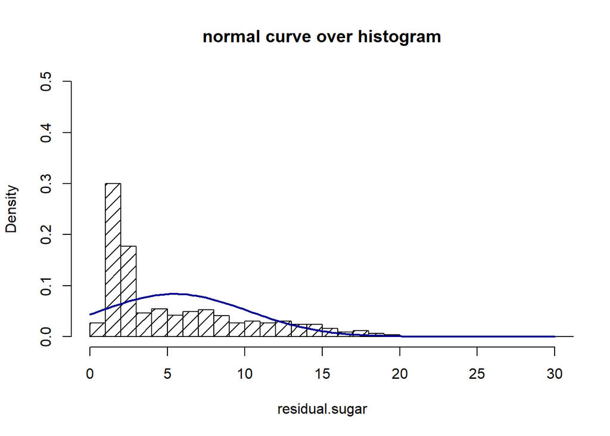

```r
m = mean(wine$residual.sugar)
std = sqrt(var(wine$residual.sugar))
hist(wine$residual.sugar, density=10, breaks=50, prob=TRUE,
xlab="residual.sugar", ylim=c(0, 0.5), xlim=c(0, 30),
main="normal curve over histogram")
curve(dnorm(x, mean=m, sd=std),
      col="darkblue", lwd=2, add=TRUE)
```